# Introduction

This study examines the relationship between the legal and illegal tobacco markets in South Africa. Section $\ref{data}$ discusses the data used and how it was cleaned. Section $\ref{methodology}$ explains the methodology, where a VECM model is presented. The final section details discussion points ($\ref{analysis}$). The appendix contains the full model outputs.

# The Illicit Tobacco Market

> “*…the supply, distribution and sale of smuggled genuine, counterfeit or cheap white tobacco products.*”

# Methodology

## Theoretical Model

$$\begin{align*}
Q_{t} = f(P_{t}, Y_{t}, D_{t})
\end{align*}$$

Where $Q_{t}$ represents cigarette consumption volume in period $t$, $P_{t}$ is the price of cigarettes adjusted for inflation, $Y_{t}$ is disposable income, and $D_{t}$ is is the dummy variable for the change in market structure that occurred in 2018.

## Data

The sample period for this study runs from January 2012 to March 2020. Monthly data is used such that there are 99 observation points for each variable in the data set. One of the advantages of using monthly data rather than annual data is that it allows for more degrees of freedom. The data used in this study include figures for South Africa for the average prices of legal cigarettes, the average prices of illicit cigarettes, volume of legal cigarettes consumed, tobacco excise duties, Value Added Tax (VAT), and real disposable income. The data for legal and illicit prices, and legal cigarette consumption are provided by a prominent South African cigarette manufacturer. The other data are extracted from the South African Reserve Bank (SARB) and Statistics South Africa (StatSA).

To prepare the legal price data for analysis, the most popular price category (MPPC) is identified as the 20-cigarette pack. A weighted average of before-tax 20-pack prices is used as a base price. The excise duty per 20’s pack and VAT are then added to the base price to calculate the price of legal cigarettes. The legal and illicit prices, and disposable income values, are adjusted for inflation, taking December 2016 as the base month and year, respectively.

The series are plotted in levels in figure $\ref{fig:plot}$ below. The general downwards trend of the graph depicting the real price of legal cigarettes suggests that inflation has been outstripping nominal cigarette prices. Real legal prices decreased slightly over the period 2012 - 2018. On the other hand, real prices for illicit cigarettes remained fairly constant from 2012 until late 2014. Following a small and sharp uptick, illicit prices slowly decreased from late 2014 until November 2018 when prices increase rapidly. The real price ratio is generally flat from 2012 - 2016, and then trends upwards slightly, implying that real legal prices were decreasing more slowly than real illicit prices were decreasing over the same period. There is a sudden drop in the price ratio in November 2018, reflecting the spike in real illicit prices. The grpahs of the respective logged series (see appendix $\ref{appendixLog}$) illustrate similar patterns.

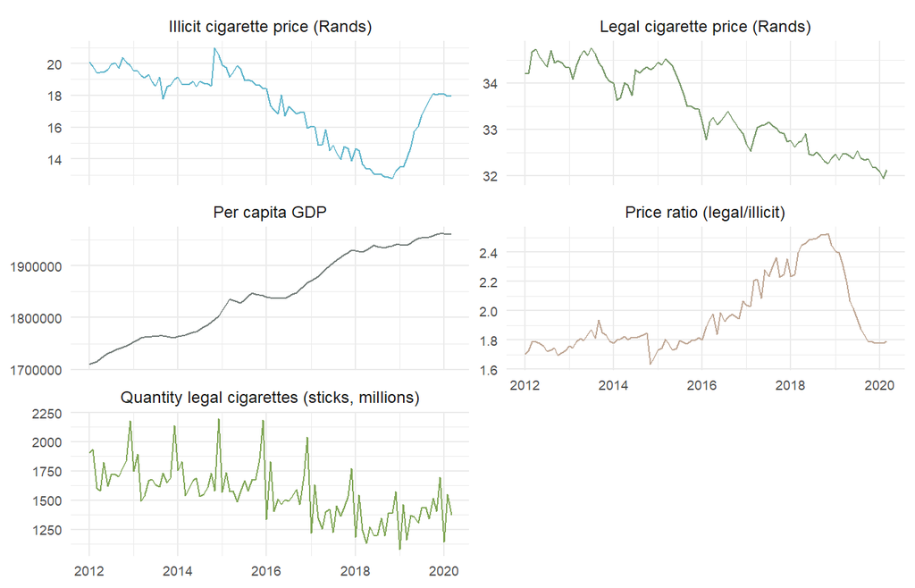

Plot for variables at levels

The graphs indicate that the series are not stationary, which is formally tested below in section $\ref{Cointegrate}$.

For the statistical analysis in sections $\ref{Cointegrate}$ and $\ref{vecm}$, all of the variables have been transformed into log form to reduce variability.

## Stationarity and Cointegration

To test whether the series are stationary, three tests were employed: the Augmented Dickey-Fuller (ADF), and Phillip-Perron (PP) unit root tests, and the Kwiatkowski–Phillips–Schmidt–Shin (KPSS) stationarity test. The results of the ADF and PP tests in figures $\ref{tab:adf}$ and $\ref{tab:pp}$ (presented in appendix $\ref{appendixA}$) show that the log of the real price ratio and the log of real per capita disposable income series are non-stationary at the 5% level of significance.

However, after first differencing each of the series, all three tests indicate that the variables are stationary at a 5% level of significance. The ADF and PP tests reject the null hypothesis that the series contain a unit root after they have been differenced, as shown in tables $\ref{adfdiff}$ and $\ref{ppdiff}$. The KPSS test fails to reject the null hypothesis of stationarity for the differenced series with p-values of 0.1 for every variable as shown in table $\ref{kpssdiff}$. Given that the series are non-stationary in levels and are stationary in first differences, a cointegration approach can be used to check whether a long-run relationship exists among the variables.

However, after testing the price ratio series, there appears to be a structural break. This may render standard unit root testing moot. Consequently, the Zivot-Andres Unit Root test was used to check for a unit root. The results are presented in table $\ref{tab:zivot}$ and show that we are unable to reject the null of a unit root, at even 10% level of significance.

To test for conintegrating relationships, two tests were employed: the Johansen Trace test for Cointegration, and the Johansen Maximum Eigenvalue test for Cointegration.

The Johansen Trace Test for Cointegration indicates that there is one cointegrating vector. As shown in table $\ref{trace}$, the test statistic of 44.1 is larger than 41.1 (the critical value at a 1% level of significance). Thus, the null hypothesis is rejected, where the null hypothesis is that there are zero cointegrating vectors. However, the test statistic 10.2 is lower than 17.9 (the critical value at a 10% level of significance). This means that the null hypothesis cannot be rejected even at a 10% signicance level, where the null hypothesis is that there is 1 or fewer cointegrating vectors.

The results of the Johansen Maximum Eigenvalue test are presented in table $\ref{eigen}$. Similar to the Trace test, the Maximum Eigenvalue test shows that there is a single cointegrating vector. The test statistic 33.9 exceeds the critical value of 26.8 at a 1% level of significance. Therefore the null hypothesis - that there is no conintegration - is rejected at a 1% significance level. However, the null hypothesis that there is 1 or fewer cointegrating relationships cannot be rejected, even at a 10% significance level. Here, the test statistics of 8.48 lies below the 10% critical value of 13.8.

The presence of a cointegrating vector indicates that a long-run relationship exist among the variables. A Vector Error Correction Model is used to combine the long and short-run dynamics. This model is presented in the following section ($\ref{vecm}$).

## Vector Error Correction Model

The VECM was with 1 cointegrating vector and at lag length of 2. The results are presented in the appendix ($\ref{appendixD}$).

$$\begin{align}
Q_t = \mu + \sum_{i = 1}^{n}\beta_iQ_{t-i} +\sum_{i =
1}^{n}\gamma_iP_{t-i} + \sum_{i = 1}^{n}\theta_iY_{t-i} \label{eq1}
\end{align}$$

where $Q_t$ is the log of legal cigarette consumption, $P_{t}$ is the log of real price ratio for cigarettes, $Y_{t}$ is the log of real disposable income, $n$ is the number of lags and $t$ is measured in months

The price ratio captures a relative change of the legal price compared to the illicit price. If the ratio shrinks, it indicates that the cost of legal cigarettes decreased relative to the cost of illicit cigarettes. There should be a negative long run relationship between the price ratio and the quantity of legal cigarettes. There should be a positive sign for the cointegrating relationship, which there is. The coefficient for the real disposable income variable should be negative for the long-run relationship (so that the reverse sign is positive); whereas the sign is positive in the Vecm results below.

The results of the diagnostic tests are shown in Appendix $\ref{appendixE}$. Table $\ref{tab:serial}$ shows the results of the serial autocorrelation test. Table $\ref{tab:arch}$ shows the arch results. Table $\ref{tab:normal}$ shows the normal results.